# Practical Machine Learning Project: Predicting Weight Lifting Movements

Warren McGee

March 22, 2015

## The data and movement classes

For more information regarding how the data was collected, please refer to section 5 and 5.1 of the group’s [paper](http://groupware.les.inf.puc-rio.br/public/papers/2013.Velloso.QAR-WLE.pdf) (1), which is summarized here.

The lab asked each of 6 participants (all male aged 20-28 years and with very little previous weightlifting experience) to do a set of 10 reps of a bicep curl using a dumbbell using one of five fashions: * **Class A**: exactly according to specification * **Class B**: throwing the elbow to the front * **Class C**: lifting the dumbbell only halfway * **Class D**: lowering the dumbbell only halfway * **Class E**: throwing the hips to the front.

Class A is the correct movement, and the other four classes are common mistakes. An experienced weightlifter was present to ensure that each participant was performing the movement they were supposed to be simulating, and they used a light weight (1.25 kg) to make sure the participants could perform the incorrect movements safely.

The data was recorded using four 9 degrees of freedom Razor inertial measurement units (IMUs), which provide acceleration, gyroscope, and magnetometer values in all 3 axes. These were placed in the users’ glove (“forearm”), armband (“arm”), lumbar belt (“belt”) and dumbbell. From these, they calculated Euler angles (roll, pitch, and yaw; see [this article](https://howthingsfly.si.edu/flight-dynamics/roll-pitch-and-yaw) for a great tutorial on what these values), as well as eight other features: mean, variance, standard deviation, max, min, amplitude, kurtosis, and skewness.

## Choice of Model: Random Forest Classifier

From class, the best performing algorithms are Random Forest Classifiers and Boost (see for example, lecture [“Random Forests”](https://class.coursera.org/predmachlearn-012/lecture) from week 3). I decided to use a Random Forest Classifier. How RF works is similar to a Classification and Regression Tree (CART): at each node of the tree, you use the predictor with the best ability to discriminate the observations to split the observations into two groups until you end up with sufficiently homogeneous subsets. The RF expands on this by using bootstrapping of both the data and the variables to construct mutliple trees, and then each constructed tree votes on how to classify each observation with a majority rule making the final determination. More information about Random Forests can been found in the [“Random Forests”](https://class.coursera.org/predmachlearn-012/lecture) lecture from week 3, or [this tutorial](http://www.stat.berkeley.edu/%7Ebreiman/RandomForests/cc_home.htm).

## Loading the data and Selection of Predictors

In order to do this work, I needed to load the *caret* and *randomForest* packages:

```r
library(caret)
library(randomForest)
```

Each observation in the training set has up to 159 potential predictors recorded to predict the class: several related to identifying the individual and the timestamp of the observation, and then several related to three fitness tracker devices (belt, forearm, and arm) and an additional device on the dumbbell. The timestamp and individual identification data won’t be useful for this exercise, so I ignored that (there was discussion in the [original paper](http://groupware.les.inf.puc-rio.br/public/papers/2013.Velloso.QAR-WLE.pdf) about using individual-level aggregate data to help in predicting data for a new participant, but that is beyond the scope of this project). Several predictors are missing a massive number of values (>97% of all observations are missing), so I decided to simply ignore these rather than attempt to impute them. This resulted in reducing the set of predictors down to 52. The code for this is shown below, along with the list of predictors retained:

```r
org.training.data <- read.csv("~/Downloads/pml-training.csv")
training.data <- org.training.data[,-1:-7]
# some columns have "" to signify missing values and have been coerced to NA, generating warnings
training.data[,-ncol(training.data)] <- suppressWarnings( apply( training.data[,-ncol(training.data)], 2, function(x) as.numeric(x) ) )
num.nas <- apply( training.data, 2, function(x) sum( is.na(x) ) )

# this number was found to be the minimum non-zero by visual inspection of num.nas
cols.2.remove <- num.nas >= 19216
clean.data <- training.data[,!cols.2.remove]
clean.vals <- clean.data[,ncol(clean.data)]
clean.predictors <- clean.data[,-ncol(clean.data)]

table(names(clean.predictors))
```

```
##
##          accel_arm_x          accel_arm_y          accel_arm_z
##                    1                    1                    1
##         accel_belt_x         accel_belt_y         accel_belt_z
##                    1                    1                    1
##     accel_dumbbell_x     accel_dumbbell_y     accel_dumbbell_z
##                    1                    1                    1
##      accel_forearm_x      accel_forearm_y      accel_forearm_z
##                    1                    1                    1
##          gyros_arm_x          gyros_arm_y          gyros_arm_z
##                    1                    1                    1
##         gyros_belt_x         gyros_belt_y         gyros_belt_z
##                    1                    1                    1
##     gyros_dumbbell_x     gyros_dumbbell_y     gyros_dumbbell_z
##                    1                    1                    1
##      gyros_forearm_x      gyros_forearm_y      gyros_forearm_z
##                    1                    1                    1
##         magnet_arm_x         magnet_arm_y         magnet_arm_z
##                    1                    1                    1
##        magnet_belt_x        magnet_belt_y        magnet_belt_z
##                    1                    1                    1
##    magnet_dumbbell_x    magnet_dumbbell_y    magnet_dumbbell_z
##                    1                    1                    1
##     magnet_forearm_x     magnet_forearm_y     magnet_forearm_z
##                    1                    1                    1
##            pitch_arm           pitch_belt       pitch_dumbbell
##                    1                    1                    1
##        pitch_forearm             roll_arm            roll_belt
##                    1                    1                    1
##        roll_dumbbell         roll_forearm      total_accel_arm
##                    1                    1                    1
##     total_accel_belt total_accel_dumbbell  total_accel_forearm
##                    1                    1                    1
##              yaw_arm             yaw_belt         yaw_dumbbell
##                    1                    1                    1
##          yaw_forearm
##                    1
```

In order to decide whether to include all of the features or to select a subset, I decided to use the *rfcv* function, using the default parameters. As seen in the table below, the reported cross validation error rate was <1% when using all predictors, as well as for half and one-quater of the predictors. With this many observations (19K), there is no danger of overfitting.

```r
set.seed(861989)
selectionTest <- rfcv(clean.predictions, clean.vals)
error.rates <- selectionTest$error.cv
error.rates
```

```
##          52          26          13           6           3           1
## 0.004382836 0.005656916 0.007134849 0.039445520 0.108500663 0.593823260
```

## Building the model and Assessing Out-of-Sample Error

As described in the [RF tutorial](http://www.stat.berkeley.edu/%7Ebreiman/RandomForests/cc_home.htm#ooberr), the out-of-bag (OOB) erorr estimate is an unbiased estimate of the out-of-sample error rate, so there is no need for cross-validation to do this. The main variable that needs to be tuned to get maximum accuracy is “mtry”, or the number of predictors to randomly select at each node to select the best discriminator. Theoretically, this number should be the floor of the square root of n, the number of predictors (in this case, 7); however, it the optimal number can sometimes vary, so one can use the *tuneRF* function from the *randomForest* package to select the optimal value for **mtry**. The code and results are shown below:

```r
set.seed(861989)
model.fit <- tuneRF(x=clean.predictors, y=clean.vals, ntreeTry=100, stepFactor=1.5, doBest=T, importance=T)
```

```
## mtry = 7  OOB error = 0.31%
## Searching left ...
## mtry = 5     OOB error = 0.41%
## -0.35 0.05
## Searching right ...
## mtry = 10    OOB error = 0.37%
## -0.2 0.05
```

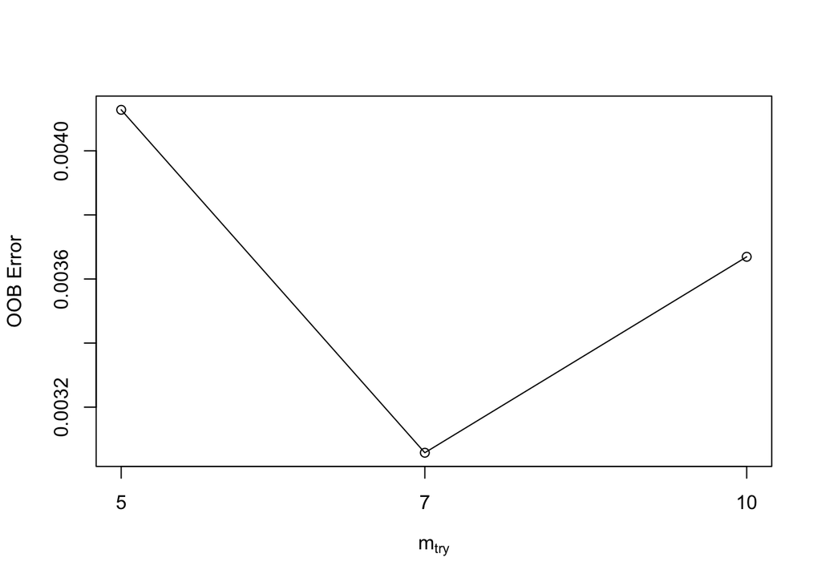

```r
oob.err <- model.fit$err.rate[nrow(model.fit$err.rate),"OOB"]
model.fit
```

```
##
## Call:
##  randomForest(x = x, y = y, mtry = res[which.min(res[, 2]), 1],      importance = ..1)
##                Type of random forest: classification
##                      Number of trees: 500
## No. of variables tried at each split: 7
##
##         OOB estimate of  error rate: 0.28%
## Confusion matrix:
##      A    B    C    D    E  class.error
## A 5577    2    0    0    1 0.0005376344
## B   10 3785    2    0    0 0.0031603898
## C    0   12 3408    2    0 0.0040911748
## D    0    0   17 3197    2 0.0059079602
## E    0    0    1    5 3601 0.0016634322
```

To see how the OOB error rate and the error rate for each class changes as the random forest adds additional trees, the randomForest object tracks this for each tree and thus this can be plotted, as shown below:

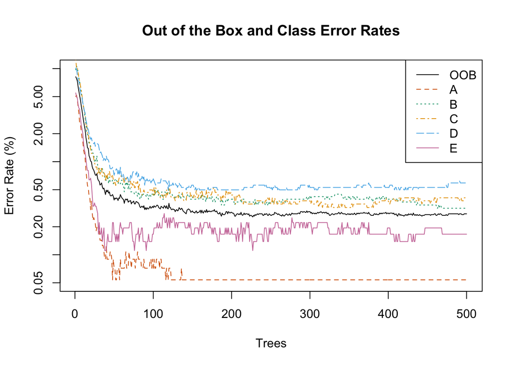

One way of interpreting how the Random Forest Classifier makes classification decisions, one can plot both the “variable importance” and the “Gini importance”. This can be done using the *varImpPlot* function. The result is shown below:

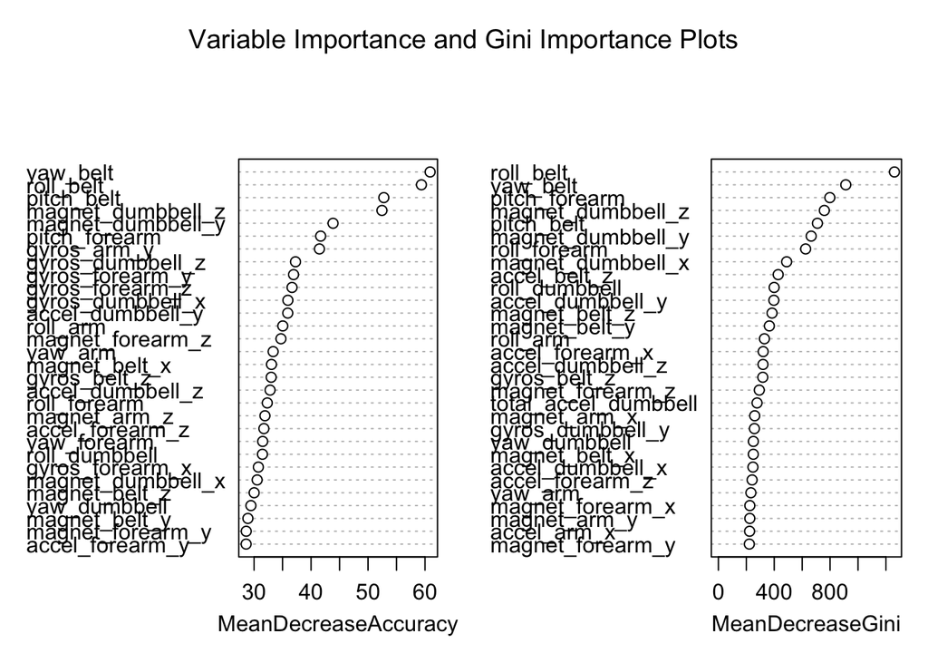

## Apply Model to Test Data and Summary

Applying the model was straightforward using the *predict* function, as shown in the code below:

```r
org.testing.data <- read.csv("~/Downloads/pml-testing.csv")
predictor.cols <- colnames(clean.data)[-length(colnames(clean.data))]
testing.data <- org.testing.data[,c(predictor.cols, "problem_id")]

preds <- predict(model.fit, testing.data)
```

## References

1. Velloso, E.; Bulling, A.; Gellersen, H.; Ugulino, W.; Fuks, H. Qualitative Activity Recognition of Weight Lifting Exercises. Proceedings of 4th International Conference in Cooperation with SIGCHI (Augmented Human ’13) . Stuttgart, Germany: ACM SIGCHI, 2013. [Link to PDF](http://groupware.les.inf.puc-rio.br/public/papers/2013.Velloso.QAR-WLE.pdf)